# 04_segmentation_seuillage_vetudiant

Ali FRADY

22/01/2021

Segmentation d’images cérébrales

Segmentation d’images par seuillage Dans cette section, il s’agit de partitionner le cerveau en 4 régions d’intérêt en utilisant une technique de seuillage simple :

1. Calculez l’histogramme de l’image « irm1_cut.jpg » et affichez-le avec la librairie matplotlib.

```python
from matplotlib import pyplot as plt
import numpy as np
import cv2
irm1_cut = cv2.imread('data/irm1_cut.jpg', 0)
plt.hist(irm1_cut.ravel(), 256, [0,256]), plt.title("histogramme de l image irm1_cut.jpg")
```

[output not shown]

[output cut: 20 more lines]

[output not shown]

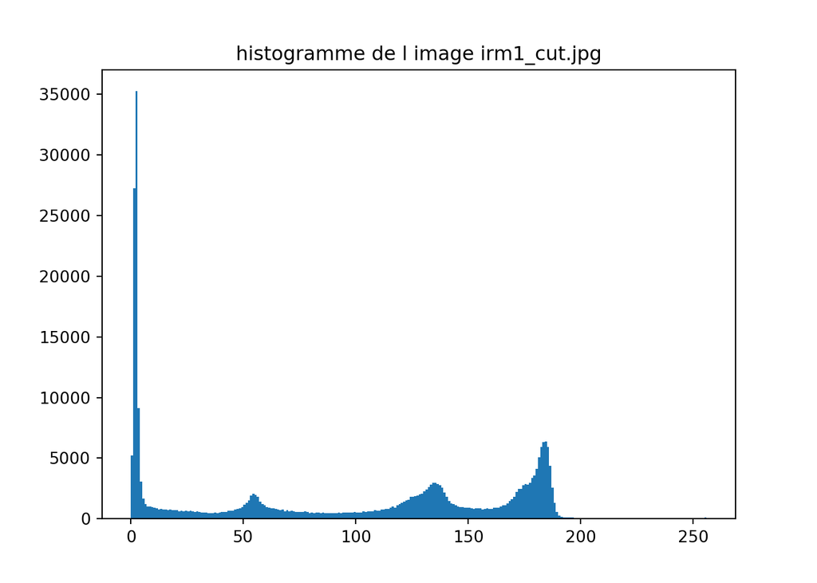

```python
plt.show()
```

2. A partir de l’histogramme de l’image définissez visuellement un seuil inférieur et un seuil supérieur d’appartenance à chaque région d’intérêt. Pour cela vous considérerez que chaque gaussienne forme une classe.

```python
BK  = range(0, 25)
CFS = range(26, 90)
GM  = range(91, 170)
WM  = range(171, 256)
```

3. Créez une nouvelle image d’étiquettes de même taille que l’image « irm1.jpg »

```python
img_etiquette = np.empty_like(irm1_cut)
```

4. A l’aide d’une boucle ‘for’ parcourez l’image d’origine et remplissez chaque pixel de l’image d’étiquettes avec l’étiquette qui lui correspond. Par exemple, un pixel qui se trouve entre 0 (seuil inférieur pour le fond) et 25 (seuil supérieur pour le fond) aura comme étiquette 0 (l’étiquette du fond).

```python
for i in range(img_etiquette.shape[0]):
  for j in range(img_etiquette.shape[1]):
    if (irm1_cut[i, j] in CFS):
      img_etiquette[i, j] = 26
    elif (irm1_cut[i, j] in GM):
      img_etiquette[i, j] = 91
    elif (irm1_cut[i, j] in WM):
      img_etiquette[i, j] = 171
    else:
      img_etiquette[i, j] = 0
```

5. Affichez l’image d’étiquettes.

```python
img_etiquette
```

```
## array([[0, 0, 0, ..., 0, 0, 0],
##        [0, 0, 0, ..., 0, 0, 0],
##        [0, 0, 0, ..., 0, 0, 0],
##        ...,
##        [0, 0, 0, ..., 0, 0, 0],
##        [0, 0, 0, ..., 0, 0, 0],
##        [0, 0, 0, ..., 0, 0, 0]], dtype=uint8)
```

6. Enregistrez l’image d’étiquettes sous le nom « segmentation_seuillage.jpg ».

```python
cv2.imwrite('data/segmentation_seuillage.jpg', img_etiquette)
```

```
## True
```

```python
irm3_cut = cv2.imread('data/irm3_cut.jpg', 0)
plt.hist(irm3_cut.ravel(), 256, [0,256]), plt.title("histogramme de l image irm3_cut.jpg")
```

[output not shown]

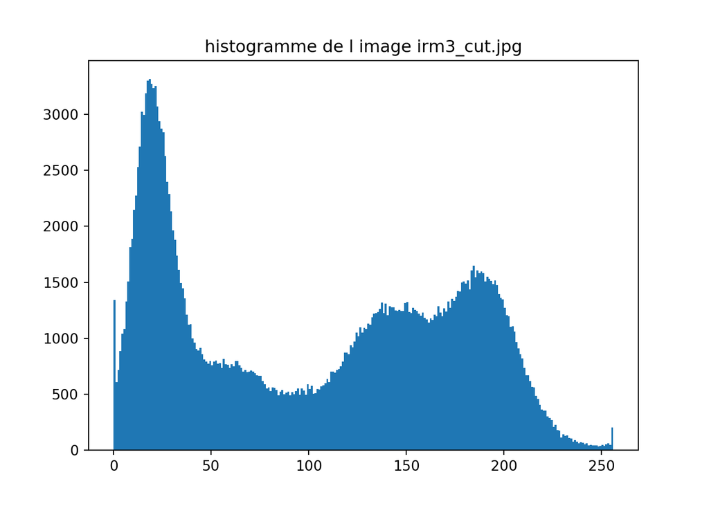

```python
plt.show()
```

```python
S1  = range(0, 50)
S2 = range(51, 80)
S3  = range(81, 160)
S4  = range(161, 256)
```

```python
img_etiquette3 = np.empty_like(irm3_cut)
```

```python
for i in range(img_etiquette3.shape[0]):
  for j in range(img_etiquette3.shape[1]):
    if (irm3_cut[i, j] in S1):
      img_etiquette3[i, j] = 0
    elif (irm3_cut[i, j] in S2):
      img_etiquette3[i, j] = 51
    elif (irm3_cut[i, j] in S3):
      img_etiquette3[i, j] = 81
    else:
      img_etiquette3[i, j] = 161
```

```python
cv2.imwrite('data/segmentation_seuillage3.jpg', img_etiquette3)
```

```
## True
```